# Exploring the Relationship Between Poverty and Air Quality in the U.S.

Karina Lakhani & Tyrone Bartholomew

GitHub Pages Link: https://kllakhani.github.io/

For our project, we decided to observe the correlation between air quality and poverty levels in counties across the United States. We want to determine if there is a significant relationship between the level of poverty of a county and the air quality in that county.

The topic aligns with both of our majors/interests, so it seemed like a natural fit. From the technological standpoint, our primary focus will be with managing and analyzing the data; from the environmental perspective we will consider the impact of the findings regarding relationship between poverty and public health (specifically around pollution).

For our analysis, we are using 2023 data since that is the last year that these datasets overlap. Our goal is to clean, merge, and then visualize the data stripped of intersecting variables to see if a trend becomes apparent. If we are able to uncover that lower income areas face worst air pollution outcomes, it will demonstrate a relationship between poverty and environment that often goes unnoticed.

# Research Questions

1. Is there a correlation between a county’s average poverty rate and its air quality (AQI)?
2. Which regions in the U.S. show the strongest link between poverty and pollution?
3. Are low-income counties exposed to disproportionately higher air pollution?

## Datasets

USDA County-Level Data Sets (2023)- [USDA County-Level Data Sets](https://www.ers.usda.gov/data-products/county-level-data-sets/county-level-data-sets-download-data)

- Includes 2023 county-level poverty rates, median household income, and unemployment rates.
2. Air Quality Data by County (EPA)- [EPA Air Quality Cities and Counties](https://www.epa.gov/air-trends/air-quality-cities-and-counties)
- Includes 2023 air quality indicators such as PM2.5, ozone levels, and days exceeding healthy AQI thresholds.

# Collaboration Plan

We work collaboratively in Google Colab and used a shared GitHub repository for version control. We decided to work asynchronously for the most part and meet up on Zoom or in person as needed.

Tonight we will publish Milestone 1 with the live link. From now to November 16 we will complete the ETL for the 2023 USDA poverty and EPA air-quality data, finalize the merged county table, and produce at least five graphics for Milestone 2. From November 16 to December 9 we will write up results, add regional analysis, choose two model directions, and build the 5–7 slide presentation and the public site.

Milestone 1:

- **Karina:** Responsible for writing, website publishing, and overall presentation.
- **Tyrone:** Responsible for ETL pipeline (loading, cleaning, and merging datasets) and generating plots/statistics.

## Extraction, Transform, and Load (ETL)

```
✅ Poverty columns: ['FIPS_Code', 'Stabr', 'Area_Name', 'Rural_Urban_Continuum_Code_2013', 'Urban_Influence_Code_2013', 'Rural_Urban_Continuum_Code_2023', 'Urban_Influence_Code_2024', 'POVALL_2023', 'CI90LBALL_2023', 'CI90UBALL_2023', 'PCTPOVALL_2023', 'CI90LBALLP_2023']
✅ Air columns: ['State', 'County', 'County FIPS Code', '2010 Population', 'CO          8-hr (ppm)', 'Pb           3-mo (µg/m3)', 'NO2         AM (ppb)', 'NO2          1-hr (ppb)', 'O3            8-hr (ppm)', 'PM10        24-hr (µg/m3) ', 'PM2.5     Wtd AM (µg/m3) ', 'PM2.5     24-hr (µg/m3) ']
Using poverty column: PCTPOVALL_2023
Using PM2.5 column: PM2.5     Wtd AM (µg/m3)

FIPS counts — poverty: 3144 air: 1145 intersection: 1121

✅ Merged sample:
    FIPS State            County  PovertyRate  PM25
0  01003    AL    Baldwin County         10.0   7.6
3  01049    AL     DeKalb County         21.6   8.9
6  01055    AL     Etowah County         19.6   9.8
8  01073    AL  Jefferson County         16.0  10.1
9  01089    AL    Madison County         10.5   8.6

Number of counties: 562
Average poverty rate: 13.23
Average PM2.5: 8.37
Correlation (poverty vs PM2.5): 0.142

Louisiana rows: 12
Avg poverty (LA): 18.58
Avg PM2.5 (LA): 8.82
LA correlation: -0.543
```

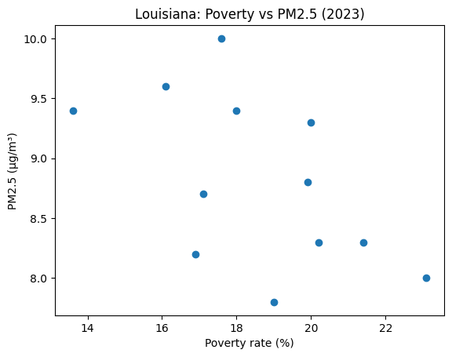

```python
# Milestone 1 - Poverty vs Air Quality (PM2.5)


import pandas as pd
import numpy as np
import matplotlib.pyplot as plt

# --- 1) Load with no header, then auto-detect the header row ---
pov_raw = pd.read_excel("Poverty2023.xlsx", header=None)
air_raw = pd.read_excel("ctyfactbook2023.xlsx", header=None)

pov_header_idx = pov_raw[0].astype(str).str.contains("FIPS", case=False, na=False).idxmax()
air_header_idx = air_raw[0].astype(str).str.contains("State", case=False, na=False).idxmax()

poverty = pd.read_excel("Poverty2023.xlsx", header=pov_header_idx)
air     = pd.read_excel("ctyfactbook2023.xlsx", header=air_header_idx)

print("✅ Poverty columns:", poverty.columns.tolist()[:12])
print("✅ Air columns:", air.columns.tolist()[:12])

# --- 2) Pick columns (poverty % + PM2.5) ---
# Poverty rate may be PCTPOVALL_2023 or POVALL_2023. Prefer PCTPOVALL_2023 if present.
pov_rate_col = "PCTPOVALL_2023" if "PCTPOVALL_2023" in poverty.columns else "POVALL_2023"
if pov_rate_col not in poverty.columns:
    raise ValueError("Couldn't find poverty rate column (looked for PCTPOVALL_2023 or POVALL_2023).")

# Find a PM2.5 column (prefer weighted annual mean if present)
pm25_cols = [c for c in air.columns if "PM2.5" in str(c)]
if not pm25_cols:
    raise ValueError("Couldn't find any PM2.5 column in the air dataset.")
pm25_col = next((c for c in pm25_cols if "Wtd" in str(c)), pm25_cols[0])

print("Using poverty column:", pov_rate_col)
print("Using PM2.5 column:", pm25_col)

# --- 3) Build small dataframes ---
pov_simple = poverty[["FIPS_Code", "Stabr", "Area_Name", pov_rate_col]].copy()
pov_simple.columns = ["FIPS", "State", "County", "PovertyRate"]

air_simple = air[["County FIPS Code", pm25_col]].copy()
air_simple.columns = ["FIPS", "PM25"]

# --- 4) Clean FIPS properly on BOTH sides ---
# Poverty FIPS are usually strings already; standardize to 5 chars.
pov_simple["FIPS"] = pov_simple["FIPS"].astype(str).str.extract(r"(\d+)")[0].str.zfill(5)

# Air FIPS often look like "10001.0" or "1003.0" -> convert safely:
air_simple["FIPS"] = pd.to_numeric(air_simple["FIPS"], errors="coerce")  # floats, NaN for junk like '00nan'
air_simple = air_simple.dropna(subset=["FIPS"])                           # drop non-FIPS rows
air_simple["FIPS"] = air_simple["FIPS"].astype(int).astype(str).str.zfill(5)

# Optional: drop state-total rows (xx000)
pov_simple = pov_simple[pov_simple["FIPS"].str[-3:] != "000"].copy()
air_simple = air_simple[air_simple["FIPS"].str[-3:] != "000"].copy()

# --- 5) Quick overlap check (should be > 0 now) ---
pov_fips = set(pov_simple["FIPS"])
air_fips = set(air_simple["FIPS"])
print("\nFIPS counts — poverty:", len(pov_fips), "air:", len(air_fips), "intersection:", len(pov_fips & air_fips))

# --- 6) Merge ---
merged = pd.merge(
    pov_simple[["FIPS","State","County","PovertyRate"]],
    air_simple[["FIPS","PM25"]],
    on="FIPS",
    how="inner"
)

# --- 7) Clean numerics & basic filters ---
merged["PovertyRate"] = pd.to_numeric(merged["PovertyRate"], errors="coerce")
merged["PM25"] = pd.to_numeric(merged["PM25"], errors="coerce")
merged = merged.dropna(subset=["PovertyRate","PM25"])
merged = merged[(merged["PovertyRate"]>=0) & (merged["PovertyRate"]<=100)]
merged = merged[(merged["PM25"]>=0) & (merged["PM25"]<200)]

print("\n✅ Merged sample:")
print(merged.head())

# --- 8) Stats ---
print("\nNumber of counties:", len(merged))
print("Average poverty rate:", round(merged["PovertyRate"].mean(), 2))
print("Average PM2.5:", round(merged["PM25"].mean(), 2))
print("Correlation (poverty vs PM2.5):", round(merged["PovertyRate"].corr(merged["PM25"]), 3))

# --- 9) Louisiana subset (uses 'State' from poverty) + plot ---
la = merged[merged["State"].astype(str).str.upper() == "LA"].copy()
print("\nLouisiana rows:", len(la))
if len(la):
    print("Avg poverty (LA):", round(la["PovertyRate"].mean(), 2))
    print("Avg PM2.5 (LA):", round(la["PM25"].mean(), 2))
    print("LA correlation:", round(la["PovertyRate"].corr(la["PM25"]), 3))

    plt.scatter(la["PovertyRate"], la["PM25"])
    plt.xlabel("Poverty rate (%)")
    plt.ylabel("PM2.5 (µg/m³)")
    plt.title("Louisiana: Poverty vs PM2.5 (2023)")
    plt.show()
else:
    print("No LA rows after merge — double-check that 'State' in poverty uses 'LA'.")
```

# Initial Observations

From a preliminary look at the data, we expect to find that counties with higher poverty levels tend to have slightly worse air quality. This may not hold true for every region but earlier studies and environmental data suggest that poorer and more industrialized counties often face higher levels of pollution.

We want to confirm this by calculating the correlation between poverty rate and AQI. If the result shows a positive correlation, it would mean that as poverty increases, air quality worsens.